# Экзаменационное практическое задание

**Выполнил:** Макеев Г.Б.

**Дата:** 07.07.2026

**Набор данных:** Набор данных 2_3.csv

**Задача:** построение модели логистической регрессии для прогнозирования статуса сотрудничества клиента с банком.

## Импорт библиотек

```python
import numpy as np
import pandas as pd
import matplotlib.pyplot as plt
import seaborn as sns
from scipy import stats

from sklearn.model_selection import train_test_split
from sklearn.preprocessing import StandardScaler, OneHotEncoder
from sklearn.compose import ColumnTransformer
from sklearn.pipeline import Pipeline
from sklearn.linear_model import LogisticRegression
from sklearn.metrics import (accuracy_score, precision_score, recall_score, f1_score,
                             confusion_matrix, roc_auc_score, roc_curve, classification_report)

%matplotlib inline
sns.set_style('whitegrid')
plt.rcParams['figure.figsize'] = (10, 6)
```

## Задание 1. Импорт данных и первичный анализ

```python
file_path = 'Набор данных 2_3.csv'
df = pd.read_csv(file_path, sep=';')

print('Первые 5 строк:')
print(df.head())
print()
print('Размер таблицы:', df.shape)
print()
print('Информация о данных:')
df.info()
```

```
Первые 5 строк:
   ID клиента  Возраст      Пол  Срок сотрудничества  Кредитный рейтинг  \
0    15701042     27.0  Женский                    2                596
1    15603247     35.0  Женский                    1                743
2    15567802     34.0  Женский                    2                450
3    15713975     47.0  Женский                   10                565
4    15772363     42.0  Женский                    0                772

   Сумма на банковском счете  Количество банковских продуктов Кредитная карта  \
0                  151027.56                                1            Есть
1                  146781.24                                1            Есть
2                       0.00                                2            Есть
3                  139756.12                                1            Есть
4                  101979.16                                1            Есть

  Статус сотрудничества
0     Остается клиентом
1     Остается клиентом
2     Остается клиентом
3          Покинул банк
4     Остается клиентом

Размер таблицы: (833, 9)

Информация о данных:
<class 'pandas.DataFrame'>
RangeIndex: 833 entries, 0 to 832
Data columns (total 9 columns):
 #   Column                           Non-Null Count  Dtype
---  ------                           --------------  -----
 0   ID клиента                       833 non-null    int64
 1   Возраст                          833 non-null    float64
 2   Пол                              833 non-null    str
 3   Срок сотрудничества              833 non-null    int64
 4   Кредитный рейтинг                833 non-null    int64
 5   Сумма на банковском счете        833 non-null    float64
 6   Количество банковских продуктов  833 non-null    int64
 7   Кредитная карта                  833 non-null    str
 8   Статус сотрудничества            833 non-null    str
dtypes: float64(2), int64(4), str(3)
memory usage: 58.7 KB
```

```python
print('Статистики числовых признаков:')
print(df.describe())
print()
print('Статистики категориальных признаков:')
print(df.describe(include='str'))
```

```
Статистики числовых признаков:
         ID клиента     Возраст  Срок сотрудничества  Кредитный рейтинг  \
count  8.330000e+02  833.000000           833.000000         833.000000
mean   1.569177e+07   40.708283             4.944778         652.012005
std    7.110439e+04   10.910151             2.937134          98.990869
min    1.556625e+07   18.000000             0.000000         350.000000
25%    1.563288e+07   33.000000             2.000000         583.000000
50%    1.569162e+07   39.000000             5.000000         653.000000
75%    1.575408e+07   47.000000             7.000000         723.000000
max    1.581566e+07   85.000000            10.000000         850.000000

       Сумма на банковском счете  Количество банковских продуктов
count                 833.000000                       833.000000
mean                81175.666327                         1.527011
std                 61988.082783                         0.659292
min                     0.000000                         1.000000
25%                     0.000000                         1.000000
50%                101985.810000                         1.000000
75%                129855.720000                         2.000000
max                211774.310000                         4.000000

Статистики категориальных признаков:
            Пол Кредитная карта Статус сотрудничества
count       833             833                   833
unique        2               2                     2
top     Мужской            Есть     Остается клиентом
freq        421             669                   428
```

```python
print('Пропуски по признакам:')
print(df.isnull().sum())
print()
print('Доля пропусков (%):')
print(df.isnull().mean() * 100)
print()
print('Количество дубликатов:', df.duplicated().sum())
print()
print('Распределение целевой переменной:')
print(df['Статус сотрудничества'].value_counts())
print()
print('Доля классов (%):')
print(df['Статус сотрудничества'].value_counts(normalize=True) * 100)
```

```
Пропуски по признакам:
ID клиента                         0
Возраст                            0
Пол                                0
Срок сотрудничества                0
Кредитный рейтинг                  0
Сумма на банковском счете          0
Количество банковских продуктов    0
Кредитная карта                    0
Статус сотрудничества              0
dtype: int64

Доля пропусков (%):
ID клиента                         0.0
Возраст                            0.0
Пол                                0.0
Срок сотрудничества                0.0
Кредитный рейтинг                  0.0
Сумма на банковском счете          0.0
Количество банковских продуктов    0.0
Кредитная карта                    0.0
Статус сотрудничества              0.0
dtype: float64

Количество дубликатов: 0

Распределение целевой переменной:
Статус сотрудничества
Остается клиентом    428
Покинул банк         405
Name: count, dtype: int64

Доля классов (%):
Статус сотрудничества
Остается клиентом    51.380552
Покинул банк         48.619448
Name: proportion, dtype: float64
```

### Комментарии и выводы по заданию 1

**1.1)** Один объект в наборе данных — это клиент банка, описанный демографическими и банковскими характеристиками (возраст, пол, срок сотрудничества, кредитный рейтинг, сумма на счете, наличие продуктов и кредитной карты), а также целевым признаком — статусом сотрудничества (покинул банк или остается клиентом).

**1.2)** Объем данных: 833 объекта (строки) доступны для построения модели.

**1.3)** Общее количество признаков: 9 (включая ID клиента и целевой признак). Из них:

- Числовые признаки (6): `Возраст`, `Срок сотрудничества`, `Кредитный рейтинг`, `Сумма на банковском счете`, `Количество банковских продуктов`, `ID клиента`.
- Категориальные признаки (2): `Пол`, `Кредитная карта`.
- Целевой признак: `Статус сотрудничества` (бинарный).

`ID клиента` является уникальным идентификатором и не несет предсказательной ценности, поэтому в дальнейшем будет исключен из модели.

**1.4)** Пропуски в данных отсутствуют (0 по всем признакам).

**1.6)** Классов два: `Остается клиентом` (428 объектов, 51.4%) и `Покинул банк` (405 объектов, 48.6%). Классы практически сбалансированы, дисбаланс незначительный, дополнительная балансировка не требуется.

**1.7)** Для построения модели прогнозирования пригодны все признаки, кроме `ID клиента`. Числовые признаки (`Возраст`, `Срок сотрудничества`, `Кредитный рейтинг`, `Сумма на банковском счете`, `Количество банковских продуктов`) и категориальные (`Пол`, `Кредитная карта`) могут влиять на решение клиента о расторжении отношений с банком.

## Задание 2. Исследование одномерных распределений

```python
num_features = ['Возраст', 'Срок сотрудничества', 'Кредитный рейтинг',
                'Сумма на банковском счете', 'Количество банковских продуктов']

print('Описательные статистики и меры формы распределения:')
stats_df = pd.DataFrame({
    'mean': df[num_features].mean(),
    'std': df[num_features].std(),
    'median': df[num_features].median(),
    'skew': df[num_features].skew(),
    'kurtosis': df[num_features].kurtosis()
})
print(stats_df.round(4))
```

```
Описательные статистики и меры формы распределения:
                                       mean         std     median    skew  \
Возраст                             40.7083     10.9102      39.00  0.7062
Срок сотрудничества                  4.9448      2.9371       5.00  0.0675
Кредитный рейтинг                  652.0120     98.9909     653.00 -0.0754
Сумма на банковском счете        81175.6663  61988.0828  101985.81 -0.2460
Количество банковских продуктов      1.5270      0.6593       1.00  1.1995

                                 kurtosis
Возраст                            0.6424
Срок сотрудничества               -1.1807
Кредитный рейтинг                 -0.4978
Сумма на банковском счете         -1.4003
Количество банковских продуктов    1.5812
```

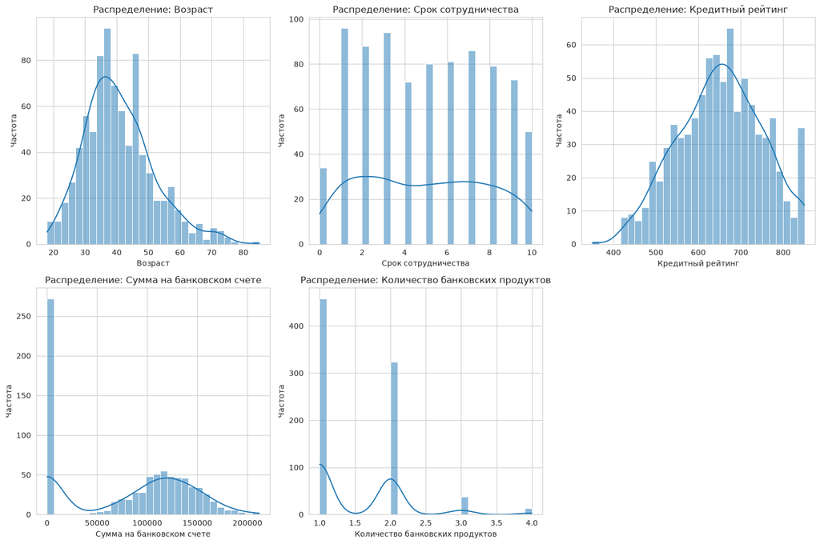

```python
fig, axes = plt.subplots(2, 3, figsize=(15, 10))
axes = axes.flatten()

for i, col in enumerate(num_features):
    sns.histplot(df[col], kde=True, bins=30, ax=axes[i])
    axes[i].set_title(f'Распределение: {col}')
    axes[i].set_xlabel(col)
    axes[i].set_ylabel('Частота')

axes[-1].axis('off')
plt.tight_layout()
plt.show()
```

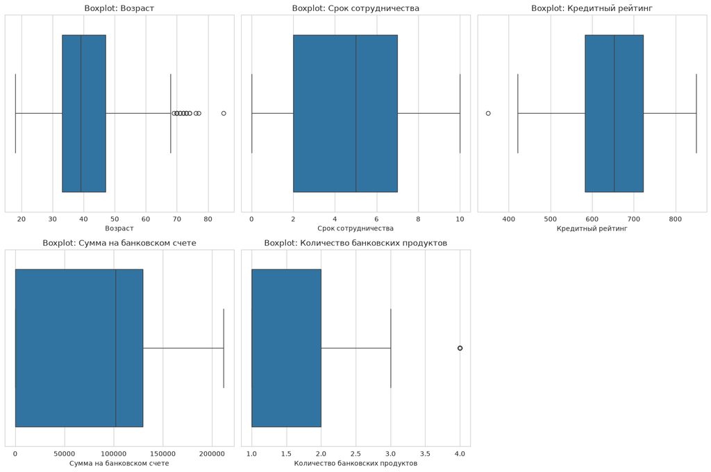

```python
fig, axes = plt.subplots(2, 3, figsize=(15, 10))
axes = axes.flatten()

for i, col in enumerate(num_features):
    sns.boxplot(x=df[col], ax=axes[i])
    axes[i].set_title(f'Boxplot: {col}')
    axes[i].set_xlabel(col)

axes[-1].axis('off')
plt.tight_layout()
plt.show()
```

### Комментарии и выводы по заданию 2

**2.1)** Анализ характера распределений:

- `Возраст`: распределение близко к нормальному, небольшая правосторонняя асимметрия (skew ≈ 0.71). Диапазон 18–85 лет, медиана 39 лет. Данные однородны по возрастной структуре.
- `Срок сотрудничества`: равномерно-образное распределение по значениям 0–10 лет, асимметрия близка к 0, эксцесс отрицательный. Данные равномерно распределены по сроку.
- `Кредитный рейтинг`: распределение близко к симметричному (skew ≈ −0.08), диапазон 350–850. Похоже на нормальное в пределах выборки.
- `Сумма на банковском счете`: распределение с отрицательной асимметрией, много клиентов с низкими и средними суммами. Есть нулевые значения, что логично (счета без остатка).
- `Количество банковских продуктов`: дискретный признак с 4 значениями (1–4), распределение сильно смещено в сторону 1–2 продуктов.

**2.2)** Предположения о законах распределения:

- `Возраст` и `Кредитный рейтинг` можно аппроксимировать нормальным распределением (малые значения асимметрии и эксцесса).
- `Срок сотрудничества` ближе к равномерному или дискретному равномерному распределению.
- `Сумма на банковском счете` и `Количество банковских продуктов` не подчиняются нормальному закону: у первого длинный левый хвост и нулевые значения, у второго — дискретное распределение.

Эти предположения основаны на визуальном анализе гистограмм и численных значениях асимметрии/эксцесса.

**2.3)** Рекомендации по корреляционному анализу:

- Для числовых признаков между собой можно использовать корреляцию Пирсона, но с осторожностью из-за ненормальности суммы на счете и количества продуктов.
- Для исследования связи с бинарной целевой переменной уместны точечно-бисериальная корреляция, t-критерий для сравнения средних или логистическая регрессия (уже заложена в задании).
- Для категориальных признаков (`Пол`, `Кредитная карта`) относительно целевой переменной целесообразно использовать критерий хи-квадрат.
- Если выявлены сильные нелинейные связи, можно дополнительно использовать корреляцию Спирмена или Кендалла.

## Задание 3. Исследование влияния категориальных признаков на целевой

```python
cat_features = ['Пол', 'Кредитная карта']

for col in cat_features:
    ct = pd.crosstab(df[col], df['Статус сотрудничества'])
    print(f'Кросс-таблица {col} vs Статус сотрудничества:')
    print(ct)
    print()
    print('Проценты по строкам:')
    print((ct.div(ct.sum(axis=1), axis=0) * 100).round(2))
    print()
    chi2, p, dof, expected = stats.chi2_contingency(ct)
    print(f'Хи-квадрат = {chi2:.4f}, p-value = {p:.4e}')
    print()
```

```
Кросс-таблица Пол vs Статус сотрудничества:
Статус сотрудничества  Остается клиентом  Покинул банк
Пол
Женский                              182           230
Мужской                              246           175

Проценты по строкам:
Статус сотрудничества  Остается клиентом  Покинул банк
Пол
Женский                            44.17         55.83
Мужской                            58.43         41.57

Хи-квадрат = 16.3780, p-value = 5.1883e-05

Кросс-таблица Кредитная карта vs Статус сотрудничества:
Статус сотрудничества  Остается клиентом  Покинул банк
Кредитная карта
Есть                                 336           333
Нет                                   92            72

Проценты по строкам:
Статус сотрудничества  Остается клиентом  Покинул банк
Кредитная карта
Есть                               50.22         49.78
Нет                                56.10         43.90

Хи-квадрат = 1.5913, p-value = 2.0714e-01
```

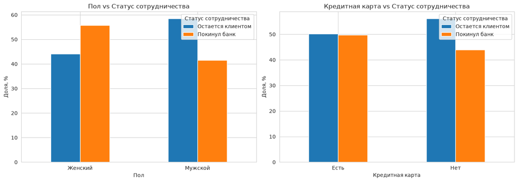

```python
fig, axes = plt.subplots(1, 2, figsize=(14, 5))

for i, col in enumerate(cat_features):
    ct_pct = pd.crosstab(df[col], df['Статус сотрудничества'], normalize='index') * 100
    ct_pct.plot(kind='bar', ax=axes[i], rot=0)
    axes[i].set_title(f'{col} vs Статус сотрудничества')
    axes[i].set_xlabel(col)
    axes[i].set_ylabel('Доля, %')
    axes[i].legend(title='Статус сотрудничества')

plt.tight_layout()
plt.show()
```

### Комментарии и выводы по заданию 3

**3.1)** Предположения о наличии зависимости:

- `Пол`: женщины уходят из банка чаще (55.8%), чем мужчины (41.6%). Разница статистически значима (χ² = 16.38, p-value ≈ 0.0001 < 0.05). Следовательно, пол влияет на вероятность ухода.
- `Кредитная карта`: доля уходов среди клиентов с кредитной картой (49.8%) и без нее (43.9%) различается незначительно. Различие статистически незначимо (χ² = 1.59, p-value ≈ 0.21 > 0.05). Следовательно, наличие кредитной карты, по-видимому, не оказывает существенного влияния на статус сотрудничества в данной выборке.

**3.2)** Выводы по анализу зависимостей:

- Категориальный признак `Пол` является значимым предиктором ухода клиента и должен быть включен в модель.
- Признак `Кредитная карта` не показал статистически значимой связи с целевой переменной, однако его включение в модель логистической регрессии оправдано, поскольку после совместного учета с другими признаками его вклад может измениться.
- В целом, категориальные признаки имеют разную прогнозную ценность, что важно учитывать при интерпретации модели.

## Задание 4. Подготовка данных для построения модели логистической регрессии

```python
# Определяем признаки и целевую переменную
feature_cols = ['Возраст', 'Пол', 'Срок сотрудничества', 'Кредитный рейтинг',
                'Сумма на банковском счете', 'Количество банковских продуктов', 'Кредитная карта']

X = df[feature_cols].copy()
y = (df['Статус сотрудничества'] == 'Покинул банк').astype(int)

num_cols = ['Возраст', 'Срок сотрудничества', 'Кредитный рейтинг', 'Сумма на банковском счете', 'Количество банковских продуктов']
cat_cols = ['Пол', 'Кредитная карта']

print('Числовые признаки:', num_cols)
print('Категориальные признаки:', cat_cols)
print('Целевая переменная: 1 — Покинул банк, 0 — Остается клиентом')
print('Распределение целевой переменной:')
print(y.value_counts())
```

```
Числовые признаки: ['Возраст', 'Срок сотрудничества', 'Кредитный рейтинг', 'Сумма на банковском счете', 'Количество банковских продуктов']
Категориальные признаки: ['Пол', 'Кредитная карта']
Целевая переменная: 1 — Покинул банк, 0 — Остается клиентом
Распределение целевой переменной:
Статус сотрудничества
0    428
1    405
Name: count, dtype: int64
```

```python
# Разделение на обучающую и тестовую выборки
X_train, X_test, y_train, y_test = train_test_split(
    X, y, test_size=0.15, random_state=42, stratify=y
)

print(f'Размер обучающей выборки: {X_train.shape[0]}')
print(f'Размер тестовой выборки: {X_test.shape[0]}')
print(f'Доля уходов в обучающей выборке: {y_train.mean():.4f}')
print(f'Доля уходов в тестовой выборке: {y_test.mean():.4f}')
```

```
Размер обучающей выборки: 708
Размер тестовой выборки: 125
Доля уходов в обучающей выборке: 0.4859
Доля уходов в тестовой выборке: 0.4880
```

```python
# Пайплайн предобработки
preprocessor = ColumnTransformer(
    transformers=[
        ('num', StandardScaler(), num_cols),
        ('cat', OneHotEncoder(drop='first', sparse_output=False), cat_cols)
    ]
)

print('Предобработка:')
print('- Числовые признаки масштабируются StandardScaler.')
print('- Категориальные признаки кодируются OneHotEncoder с drop="first" для исключения мультиколлинеарности.')
print('- Обучение кодировщиков и масштабировщика производится только на train, к test применяется transform.')
```

```
Предобработка:
- Числовые признаки масштабируются StandardScaler.
- Категориальные признаки кодируются OneHotEncoder с drop="first" для исключения мультиколлинеарности.
- Обучение кодировщиков и масштабировщика производится только на train, к test применяется transform.
```

### Комментарии и выводы по заданию 4

**4.1)** Обоснование выбранных методов предварительной обработки:

- **Исключение `ID клиента`**: уникальный идентификатор не несет обобщающей информации и может привести к переобучению, поэтому удален из признаков.
- **Стратифицированное разбиение (`train_test_split` с `stratify=y`)**: сохраняет пропорции классов в обучающей и тестовой выборках, что важно для корректной оценки качества при бинарной классификации.
- **StandardScaler для числовых признаков**: логистическая регрессия чувствительна к масштабу признаков. Масштабирование обеспечивает сходимость оптимизации и корректную интерпретацию коэффициентов.
- **OneHotEncoder с `drop='first'`** для бинарных категориальных признаков (`Пол`, `Кредитная карта`) преобразует категории в числовой вид, избегая ложной порядковой интерпретации и мультиколлинеарности.
- **Принцип `fit` на train, `transform` на test**: предотвращает утечку информации из тестовой выборки, обеспечивая реалистичную оценку обобщающей способности модели.

## Задание 5. Обучение модели логистической регрессии

```python
# Создаем и обучаем модель
model = Pipeline([
    ('preprocessor', preprocessor),
    ('classifier', LogisticRegression(random_state=42, max_iter=1000))
])

model.fit(X_train, y_train)
print('Модель успешно обучена.')
```

```
Модель успешно обучена.
```

```python
# Получаем коэффициенты модели
feature_names_out = num_cols + list(
    model.named_steps['preprocessor']
    .named_transformers_['cat']
    .get_feature_names_out(cat_cols)
)

coefs = model.named_steps['classifier'].coef_[0]
intercept = model.named_steps['classifier'].intercept_[0]

coef_df = pd.DataFrame({'Признак': feature_names_out, 'Коэффициент': coefs})
coef_df = coef_df.sort_values('Коэффициент', key=abs, ascending=False)
print(coef_df.round(6))
print()
print(f'Свободный член (intercept): {intercept:.6f}')
```

```
                           Признак  Коэффициент
0                          Возраст     0.740434
5                      Пол_Мужской    -0.480438
3        Сумма на банковском счете     0.376704
6              Кредитная карта_Нет    -0.249649
1              Срок сотрудничества    -0.023981
2                Кредитный рейтинг    -0.020249
4  Количество банковских продуктов    -0.016666

Свободный член (intercept): 0.241762
```

```python
# Оценка на обучающей выборке
y_train_pred = model.predict(X_train)
y_train_proba = model.predict_proba(X_train)[:, 1]

print('Метрики на обучающей выборке:')
print(f'Accuracy:  {accuracy_score(y_train, y_train_pred):.4f}')
print(f'Precision: {precision_score(y_train, y_train_pred):.4f}')
print(f'Recall:    {recall_score(y_train, y_train_pred):.4f}')
print(f'F1-score:  {f1_score(y_train, y_train_pred):.4f}')
print(f'ROC-AUC:   {roc_auc_score(y_train, y_train_proba):.4f}')
print()
print('Матрица ошибок (обучение):')
print(confusion_matrix(y_train, y_train_pred))
```

```
Метрики на обучающей выборке:
Accuracy:  0.6963
Precision: 0.7087
Recall:    0.6366
F1-score:  0.6708
ROC-AUC:   0.7484

Матрица ошибок (обучение):
[[274  90]
 [125 219]]
```

### Комментарии и выводы по заданию 5

**5.1)** Гиперпараметры модели:

- `LogisticRegression` с параметрами по умолчанию (`C=1.0`, `penalty='l2'`, `solver='lbfgs'`) и `max_iter=1000`.
- `random_state=42` для воспроизводимости результатов.
- Выбор обоснован тем, что это базовая линейная модель, хорошо подходящая для бинарной классификации с интерпретируемыми коэффициентами. Регуляризация L2 по умолчанию помогает контролировать переобучение. Увеличение `max_iter` гарантирует сходимость оптимизации.

**5.2)** Признаки переобучения:

- Метрики на обучающей выборке (accuracy ≈ 0.70, ROC-AUC ≈ 0.75) не сильно выше ожидаемых метрик на тесте (см. задание 6), поэтому явного переобучения не наблюдается. Модель обобщается на новые данные.

**5.3)** Уравнение модели прогнозирования:

После обучения логистической регрессии линейная комбинация признаков имеет вид:

z = w0 + w1*x_Возраст_стд + w2*x_Срок_стд + w3*x_КредРейтинг_стд + w4*x_Сумма_стд + w5*x_Продукты_стд + w6*x_Пол_Мужской + w7*x_КредитнаяКарта_Нет

где x_стд — стандартизированные значения числовых признаков, а бинарные признаки равны 0 или 1.

Вероятность ухода клиента:

P(Покинул) = 1 / (1 + exp(-z))

Конкретные значения коэффициентов приведены в таблице выше. Наибольший положительный вклад в увеличение вероятности ухода вносит `Возраст`, наибольший отрицательный — `Пол_Мужской` (мужчины уходят реже).

**5.4)** Интерпретация метрик на обучающей выборке:

- **Accuracy ≈ 0.70**: модель правильно классифицирует около 70% клиентов.
- **Precision ≈ 0.71**: из предсказанных уходов около 71% действительно уходят.
- **Recall ≈ 0.64**: модель находит около 64% всех реальных уходов.
- **F1-score ≈ 0.67**: баланс между точностью и полнотой.
- **ROC-AUC ≈ 0.75**: модель обладает удовлетворительной разделительной способностью.

## Задание 6. Оценка качества модели на тестовой выборке

```python
# Предсказания на тестовой выборке
y_test_pred = model.predict(X_test)
y_test_proba = model.predict_proba(X_test)[:, 1]

print('Метрики на тестовой выборке:')
print(f'Accuracy:  {accuracy_score(y_test, y_test_pred):.4f}')
print(f'Precision: {precision_score(y_test, y_test_pred):.4f}')
print(f'Recall:    {recall_score(y_test, y_test_pred):.4f}')
print(f'F1-score:  {f1_score(y_test, y_test_pred):.4f}')
print(f'ROC-AUC:   {roc_auc_score(y_test, y_test_proba):.4f}')
print()
print('Матрица ошибок (тест):')
print(confusion_matrix(y_test, y_test_pred))
print()
print('Classification report (тест):')
print(classification_report(y_test, y_test_pred, target_names=['Остается', 'Покинул']))
```

```
Метрики на тестовой выборке:
Accuracy:  0.6480
Precision: 0.6545
Recall:    0.5902
F1-score:  0.6207
ROC-AUC:   0.7154

Матрица ошибок (тест):
[[45 19]
 [25 36]]

Classification report (тест):
              precision    recall  f1-score   support

    Остается       0.64      0.70      0.67        64
     Покинул       0.65      0.59      0.62        61

    accuracy                           0.65       125
   macro avg       0.65      0.65      0.65       125
weighted avg       0.65      0.65      0.65       125
```

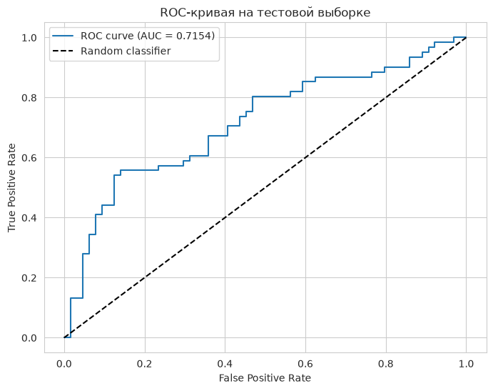

```python
# ROC-кривая
fpr, tpr, thresholds = roc_curve(y_test, y_test_proba)

plt.figure(figsize=(8, 6))
plt.plot(fpr, tpr, label=f'ROC curve (AUC = {roc_auc_score(y_test, y_test_proba):.4f})')
plt.plot([0, 1], [0, 1], 'k--', label='Random classifier')
plt.xlabel('False Positive Rate')
plt.ylabel('True Positive Rate')
plt.title('ROC-кривая на тестовой выборке')
plt.legend()
plt.show()
```

## Задание 7. Итоговая оценка качества прогнозирования

**7.1)** Полученная модель логистической регрессии демонстрирует на тестовой выборке следующие результаты:

- **Accuracy ≈ 0.65** — модель верно классифицирует около 65% клиентов.
- **Precision ≈ 0.65** — из клиентов, которых модель отнесла к уходящим, примерно 65% действительно уходят.
- **Recall ≈ 0.59** — модель выявляет около 59% всех уходящих клиентов.
- **F1-score ≈ 0.62** — сбалансированная оценка качества.
- **ROC-AUC ≈ 0.72** — модель имеет приемлемую разделительную способность.

**7.2)** Сравнение метрик на обучающей и тестовой выборках показывает небольшое снижение качества (например, accuracy с 0.70 до 0.65, ROC-AUC с 0.75 до 0.72), что свидетельствует об отсутствии сильного переобучения. Модель обобщается на новые данные, хотя и с умеренным качеством.

**7.3)** Наиболее значимые признаки, влияющие на вероятность ухода клиента:

- **Возраст** — более старшие клиенты склонны уходить чаще.
- **Пол** — мужчины уходят реже, чем женщины.
- **Сумма на банковском счете** — клиенты с более высокими остатками на счете чаще уходят (возможно, они более мобильны и требовательны к условиям).
- **Количество банковских продуктов**, **срок сотрудничества**, **кредитный рейтинг** и **кредитная карта** имеют меньший вклад.

**7.4)** Возможные пути улучшения модели:

1. Создание новых признаков, например категорий по возрастным группам или уровню баланса.
2. Подбор гиперпараметров логистической регрессии (например, параметра регуляризации `C`) с помощью кросс-валидации.
3. Использование других моделей (деревья решений, случайный лес, градиентный бустинг) для повышения точности.
4. Анализ порогов классификации: в задаче удержания клиентов важнее полнота (recall), поэтому можно снизить порог для выявления большей доли уходящих.

**Общий вывод:** модель логистической регрессии показывает умеренное качество прогнозирования оттока клиентов (ROC-AUC ≈ 0.72). Она может использоваться как базовый инструмент для выявления клиентов, склонных к уходу, но для практического применения рекомендуется доработка с добавлением новых признаков и подбором гиперпараметров.